# What my YouTube log says about me

## What I tracked

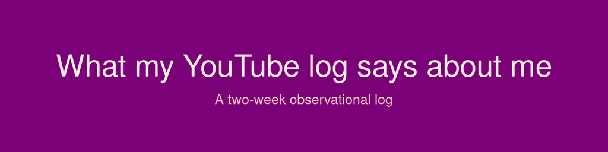

Deep purple banner reading “What my YouTube log says about me” with the subtitle “A two-week observational log”

I logged every YouTube video I watched using a Google Form across two separate weeks of the semester, six weeks apart. Each entry recorded the video’s category, how long it ran in minutes, how I found it, and a rating out of ten. The form’s automatic timestamp captured when each entry was submitted.

The goal was to look at three things: what I actually watch, when I watch it, and whether I enjoy what the algorithm puts in front of me. The three plots that follow each take on one of those questions.

## What I actually watch

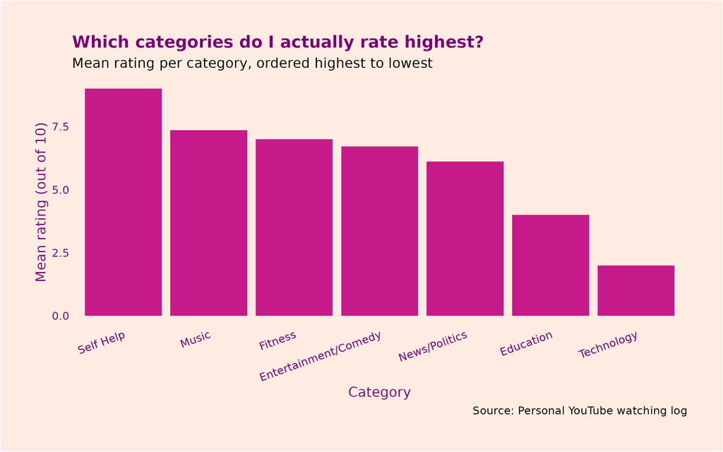

Bar chart of mean rating per category, ordered highest to lowest. Self Help sits highest at 9 out of 10, followed by Music, Fitness, Entertainment, News, Education, and Technology lowest at 2.

The categories I rate highest are not the categories I watch most often. Self Help comes out on top of my ratings with a mean of 9 out of 10, even though I only logged three of those videos. Music, which I watched fourteen times, sits below it on rating despite dominating my view count.

That gap is worth sitting with. It suggests the algorithm is winning the battle for my watch time while losing the battle for my satisfaction.

## When I watch

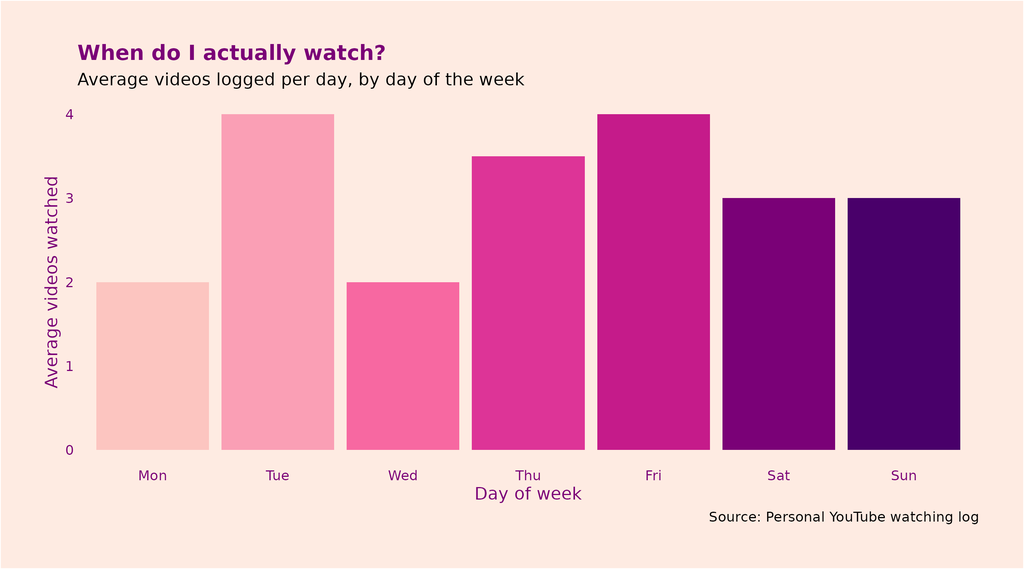

Bar chart of average videos logged per day, by day of the week, coloured from pale pink for Monday through to deep purple for Sunday. Tuesday and Friday tie at the highest with an average of four videos each; Monday and Wednesday sit lowest at an average of two.

The weekly rhythm is clear. Tuesday and Friday are my heaviest days at an average of four videos each, Thursday close behind at three and a half, and the weekend sits steady at three. Monday and Wednesday drop to just two.

The pattern says my watching is shaped by routine more than mood. The two heaviest days book-end the working week, the weekend stays consistent, and Wednesday is a clear dip. That kind of repeating weekly shape only shows up if the underlying habit is regular.

## The top three, against my average

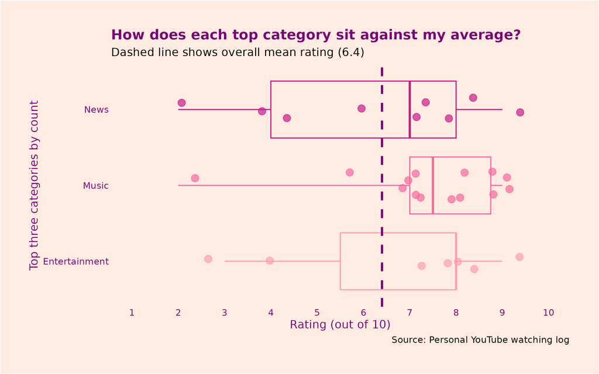

Three horizontal box plots with jittered points overlaid, showing rating spread for Music, News and Entertainment, my three most-logged categories. A dashed vertical line marks my overall mean rating at 6.4. Music sits clearly above the line with the tightest box; News and Entertainment have wider spreads that cross the line.

All three of my top categories have their medians sitting at or above the dashed line at 6.4, which says my heavy watching is not actively making me unhappy. Music sits the most consistently above the line, with most of its ratings clustered between 7 and 9.